# Projeto 1 - Logística prevendo o consumo de energia de carros elétricos

# Descrição projeto

Uma empresa da área de transporte e logística deseja migrar sua frota para carros elétricos com o objetivo de reduzir os custos. Antes de tomar a decisão, a empresa gostaria de prever o consumo de energia de carros elétricos com base em diversos fatores de utilização e características dos veículos. Usando um incrível dataset com dados reais disponíveis publicamente, você deverá construir um modelo de machine Learning capaz de prever o consumo de energia de carros elétricos com base em diversos fatores, tais como o tipo e número de motores elétricos do veículo, o peso do veículo, a capacidade de carga, entre outros atributos.

# Base dados

Para a construção desse projeto, recomendamos a utilização da linguagem R e o dataset disponível para download no link abaixo: https://data.mendeley.com/datasets/tb9yrptydn/2

Este conjunto de dados lista todos os carros totalmente elétricos com seus atributos (propriedades) disponíveis atualmente no mercado. A coleção não contém dados sobre carros híbridos e carros elétricos dos chamados “extensores de alcance”. Os carros a hidrogênio também não foram incluídos no conjunto de dados devido ao número insuficiente de modelos produzidos em massa e à especificidade diferente (em comparação com veículo elétrico) do veículo, incluindo os diferentes métodos de carregamento. O conjunto de dados inclui carros que, a partir de 2 de dezembro de 2020, poderiam ser adquiridos na Polônia como novos em um revendedor autorizado e aqueles disponíveis em prévenda pública e geral, mas apenas se uma lista de preços publicamente disponível com versões de equipamentos e parâmetros técnicos completos estivesse disponível. A lista não inclui carros descontinuados que não podem ser adquiridos como novos de um revendedor autorizado (também quando não estão disponíveis em estoque). O conjunto de dados de carros elétricos inclui todos os carros totalmente elétricos no mercado primário que foram obtidos de materiais oficiais (especificações técnicas e catálogos) fornecidos por fabricantes de automóveis com licença para vender carros na Polônia. Esses materiais foram baixados de seus sites oficiais. Caso os dados fornecidos pelo fabricante estivessem incompletos, as informações eram complementadas com dados do AutoCatálogo SAMAR (link disponível na seção Referências da fonte de dados).

Objetivo projeto Seu trabalho é construir um modelo de Machine Learning capaz de prever o consumo de energia de veículos elétricos.

Citação Esse curso da formação cientist de dados da @Data Science Academy

Instalação pacotes

```r
install.packages("naniar")
```

```
Error in install.packages : Updating loaded packages
```

```r
install.packages("sqldf")
```

```
Error in install.packages : Updating loaded packages
```

Importando bibliotecas

```r
library("readxl")
library("naniar")
library("corrplot")
library("dplyr")
library("sqldf")
library("ggplot2")
library("caret")
library("repr")
```

Base dados

```r
dados <- read_excel("1.Machine Learning - Logística prevendo o consumo de energia de carros elétricos/FEV-data-Excel.xlsx")
```

[output not shown]

```r
dados
```

| Car full name | Make | Model | Minimal price (gross) [PLN] | Engine power [KM] | Maximum torque [Nm] | Type of brakes | Drive type | Battery capacity [kWh] | Range (WLTP) [km] | Wheelbase [cm] | Length [cm] | Width [cm] | Height [cm] | Minimal empty weight [kg] | Permissable gross weight [kg] | Maximum load capacity [kg] | Number of seats | Number of doors | Tire size [in] | Maximum speed [kph] | Boot capacity (VDA) [l] | Acceleration 0-100 kph [s] | Maximum DC charging power [kW] | mean - Energy consumption [kWh/100 km] |
| --- | --- | --- | --- | --- | --- | --- | --- | --- | --- | --- | --- | --- | --- | --- | --- | --- | --- | --- | --- | --- | --- | --- | --- | --- |
| Audi e-tron 55 quattro | Audi | e-tron 55 quattro | 345700 | 360 | 664 | disc (front + rear) | 4WD | 95.0 | 438 | 292.8 | 490.1 | 193.5 | 162.9 | 2565 | 3130 | 640 | 5 | 5 | 19 | 200 | 660 | 5.7 | 150 | 24.45 |
| Audi e-tron 50 quattro | Audi | e-tron 50 quattro | 308400 | 313 | 540 | disc (front + rear) | 4WD | 71.0 | 340 | 292.8 | 490.1 | 193.5 | 162.9 | 2445 | 3040 | 670 | 5 | 5 | 19 | 190 | 660 | 6.8 | 150 | 23.80 |
| Audi e-tron S quattro | Audi | e-tron S quattro | 414900 | 503 | 973 | disc (front + rear) | 4WD | 95.0 | 364 | 292.8 | 490.2 | 197.6 | 162.9 | 2695 | 3130 | 565 | 5 | 5 | 20 | 210 | 660 | 4.5 | 150 | 27.55 |
| Audi e-tron Sportback 50 quattro | Audi | e-tron Sportback 50 quattro | 319700 | 313 | 540 | disc (front + rear) | 4WD | 71.0 | 346 | 292.8 | 490.1 | 193.5 | 161.6 | 2445 | 3040 | 640 | 5 | 5 | 19 | 190 | 615 | 6.8 | 150 | 23.30 |
| Audi e-tron Sportback 55 quattro | Audi | e-tron Sportback 55 quattro | 357000 | 360 | 664 | disc (front + rear) | 4WD | 95.0 | 447 | 292.8 | 490.1 | 193.5 | 161.6 | 2595 | 3130 | 670 | 5 | 5 | 19 | 200 | 615 | 5.7 | 150 | 23.85 |
| Audi e-tron Sportback S quattro | Audi | e-tron Sportback S quattro | 426200 | 503 | 973 | disc (front + rear) | 4WD | 95.0 | 369 | 292.8 | 490.2 | 197.6 | 161.5 | 2695 | 3130 | 565 | 5 | 5 | 20 | 210 | 615 | 4.5 | 150 | 27.20 |
| BMW i3 | BMW | i3 | 169700 | 170 | 250 | disc (front + rear) | 2WD (rear) | 42.2 | 359 | 257.0 | 400.6 | 179.1 | 157.0 | 1440 | 1730 | 440 | 4 | 5 | 19 | 160 | 260 | 8.1 | 50 | 13.10 |
| BMW i3s | BMW | i3s | 184200 | 184 | 270 | disc (front + rear) | 2WD (rear) | 42.2 | 345 | 257.0 | 400.6 | 179.1 | 159.0 | 1460 | 1730 | 440 | 4 | 5 | 20 | 160 | 260 | 6.9 | 50 | 14.30 |
| BMW iX3 | BMW | iX3 | 282900 | 286 | 400 | disc (front + rear) | 2WD (rear) | 80.0 | 460 | 286.4 | 473.4 | 189.1 | 166.8 | 2260 | 2725 | 540 | 5 | 5 | 19 | 180 | 510 | 6.8 | 150 | 18.80 |
| Citroën ë-C4 | Citroën | ë-C4 | 125000 | 136 | 260 | disc (front + rear) | 2WD (front) | 50.0 | 350 | 266.7 | 435.4 | 180.0 | 152.2 | 1541 | 2000 | 459 | 5 | 5 | 16 | 150 | 380 | 9.5 | 100 | NA |

[output cut: 43 more lines]

# Verificando as tabelas

```r
# Verficando número de linhas
nrow(dados)
```

```
[1] 53
```

```r
# Linhas e colunas
dim(dados)
```

```
[1] 53 25
```

```r
# Verificando os cienco primeiros dados
head(dados)
```

| Car full name | Make | Model | Minimal price (gross) [PLN] | Engine power [KM] | Maximum torque [Nm] | Type of brakes | Drive type | Battery capacity [kWh] | Range (WLTP) [km] | Wheelbase [cm] | Length [cm] | Width [cm] | Height [cm] | Minimal empty weight [kg] | Permissable gross weight [kg] | Maximum load capacity [kg] | Number of seats | Number of doors | Tire size [in] | Maximum speed [kph] | Boot capacity (VDA) [l] | Acceleration 0-100 kph [s] | Maximum DC charging power [kW] | mean - Energy consumption [kWh/100 km] |
| --- | --- | --- | --- | --- | --- | --- | --- | --- | --- | --- | --- | --- | --- | --- | --- | --- | --- | --- | --- | --- | --- | --- | --- | --- |
| Audi e-tron 55 quattro | Audi | e-tron 55 quattro | 345700 | 360 | 664 | disc (front + rear) | 4WD | 95 | 438 | 292.8 | 490.1 | 193.5 | 162.9 | 2565 | 3130 | 640 | 5 | 5 | 19 | 200 | 660 | 5.7 | 150 | 24.45 |
| Audi e-tron 50 quattro | Audi | e-tron 50 quattro | 308400 | 313 | 540 | disc (front + rear) | 4WD | 71 | 340 | 292.8 | 490.1 | 193.5 | 162.9 | 2445 | 3040 | 670 | 5 | 5 | 19 | 190 | 660 | 6.8 | 150 | 23.80 |
| Audi e-tron S quattro | Audi | e-tron S quattro | 414900 | 503 | 973 | disc (front + rear) | 4WD | 95 | 364 | 292.8 | 490.2 | 197.6 | 162.9 | 2695 | 3130 | 565 | 5 | 5 | 20 | 210 | 660 | 4.5 | 150 | 27.55 |
| Audi e-tron Sportback 50 quattro | Audi | e-tron Sportback 50 quattro | 319700 | 313 | 540 | disc (front + rear) | 4WD | 71 | 346 | 292.8 | 490.1 | 193.5 | 161.6 | 2445 | 3040 | 640 | 5 | 5 | 19 | 190 | 615 | 6.8 | 150 | 23.30 |
| Audi e-tron Sportback 55 quattro | Audi | e-tron Sportback 55 quattro | 357000 | 360 | 664 | disc (front + rear) | 4WD | 95 | 447 | 292.8 | 490.1 | 193.5 | 161.6 | 2595 | 3130 | 670 | 5 | 5 | 19 | 200 | 615 | 5.7 | 150 | 23.85 |
| Audi e-tron Sportback S quattro | Audi | e-tron Sportback S quattro | 426200 | 503 | 973 | disc (front + rear) | 4WD | 95 | 369 | 292.8 | 490.2 | 197.6 | 161.5 | 2695 | 3130 | 565 | 5 | 5 | 20 | 210 | 615 | 4.5 | 150 | 27.20 |

```r
# Verificando os últimos dados
tail(dados)
```

| Car full name | Make | Model | Minimal price (gross) [PLN] | Engine power [KM] | Maximum torque [Nm] | Type of brakes | Drive type | Battery capacity [kWh] | Range (WLTP) [km] | Wheelbase [cm] | Length [cm] | Width [cm] | Height [cm] | Minimal empty weight [kg] | Permissable gross weight [kg] | Maximum load capacity [kg] | Number of seats | Number of doors | Tire size [in] | Maximum speed [kph] | Boot capacity (VDA) [l] | Acceleration 0-100 kph [s] | Maximum DC charging power [kW] | mean - Energy consumption [kWh/100 km] |
| --- | --- | --- | --- | --- | --- | --- | --- | --- | --- | --- | --- | --- | --- | --- | --- | --- | --- | --- | --- | --- | --- | --- | --- | --- |
| Volkswagen ID.3 Pro Performance | Volkswagen | ID.3 Pro Performance | 155890 | 204 | 310 | disc (front) + drum (rear) | 2WD (rear) | 58 | 425 | 277.0 | 426.1 | 180.9 | 156.8 | 1805 | 2270 | 540 | 5 | 5 | 18 | 160 | 385 | 7.3 | 100 | 15.4 |
| Volkswagen ID.3 Pro S | Volkswagen | ID.3 Pro S | 179990 | 204 | 310 | disc (front) + drum (rear) | 2WD (rear) | 77 | 549 | 277.0 | 426.1 | 180.9 | 156.8 | 1934 | 2280 | 412 | 5 | 5 | 19 | 160 | 385 | 7.9 | 125 | 15.9 |
| Volkswagen ID.4 1st | Volkswagen | ID.4 1st | 202390 | 204 | 310 | disc (front) + drum (rear) | 2WD (rear) | 77 | 500 | 277.1 | 458.4 | 185.2 | 163.1 | 2124 | 2660 | 661 | 5 | 5 | 20 | 160 | 543 | 8.5 | 125 | 18.0 |
| Citroën ë-Spacetourer (M) | Citroën | ë-Spacetourer (M) | 215400 | 136 | 260 | disc (front + rear) | 2WD (front) | 50 | 230 | 327.5 | 459.9 | 192.0 | 190.0 | 1969 | 2810 | 1056 | 8 | 5 | 16 | 130 | 603 | 13.1 | 100 | 25.2 |
| Mercedes-Benz EQV (long) | Mercedes-Benz | EQV (long) | 339480 | 204 | 362 | NA | 2WD (front) | 90 | 356 | 320.0 | 514.0 | 192.8 | 191.0 | 2710 | 3500 | 865 | 6 | 5 | 17 | 160 | NA | NA | 110 | 28.2 |
| Nissan e-NV200 evalia | Nissan | e-NV200 evalia | 164328 | 109 | 254 | disc (front + rear) | 2WD (front) | 40 | 200 | 272.5 | 456.0 | 175.5 | 185.8 | 1592 | 2250 | 658 | 5 | 5 | 15 | 123 | 870 | NA | 50 | 25.9 |

```r
# Resumo estatístico das variáveis numéricas
summary(dados)
```

```
 Car full name          Make              Model           Minimal price (gross) [PLN]
 Length:53          Length:53          Length:53          Min.   : 82050
 Class :character   Class :character   Class :character   1st Qu.:142900
 Mode  :character   Mode  :character   Mode  :character   Median :178400
                                                          Mean   :246159
                                                          3rd Qu.:339480
                                                          Max.   :794000

 Engine power [KM] Maximum torque [Nm] Type of brakes      Drive type        Battery capacity [kWh]
 Min.   : 82.0     Min.   : 160        Length:53          Length:53          Min.   : 17.60
 1st Qu.:136.0     1st Qu.: 260        Class :character   Class :character   1st Qu.: 40.00
 Median :204.0     Median : 362        Mode  :character   Mode  :character   Median : 58.00
 Mean   :269.8     Mean   : 460                                              Mean   : 62.37
 3rd Qu.:372.0     3rd Qu.: 640                                              3rd Qu.: 80.00
 Max.   :772.0     Max.   :1140                                              Max.   :100.00

 Range (WLTP) [km] Wheelbase [cm]   Length [cm]      Width [cm]     Height [cm]
 Min.   :148.0     Min.   :187.3   Min.   :269.5   Min.   :164.5   Min.   :137.8
 1st Qu.:289.0     1st Qu.:258.8   1st Qu.:411.8   1st Qu.:178.8   1st Qu.:148.1
 Median :364.0     Median :270.0   Median :447.0   Median :180.9   Median :155.6
 Mean   :376.9     Mean   :273.6   Mean   :442.5   Mean   :186.2   Mean   :155.4
 3rd Qu.:450.0     3rd Qu.:290.0   3rd Qu.:490.1   3rd Qu.:193.5   3rd Qu.:161.5
 Max.   :652.0     Max.   :327.5   Max.   :514.0   Max.   :255.8   Max.   :191.0

 Minimal empty weight [kg] Permissable gross weight [kg] Maximum load capacity [kg] Number of seats
 Min.   :1035              Min.   :1310                  Min.   : 290.0             Min.   :2.000
 1st Qu.:1530              1st Qu.:1916                  1st Qu.: 440.0             1st Qu.:5.000
 Median :1685              Median :2119                  Median : 486.0             Median :5.000
 Mean   :1868              Mean   :2289                  Mean   : 520.5             Mean   :4.906
 3rd Qu.:2370              3rd Qu.:2870                  3rd Qu.: 575.0             3rd Qu.:5.000
 Max.   :2710              Max.   :3500                  Max.   :1056.0             Max.   :8.000
                           NA's   :8                     NA's   :8
 Number of doors Tire size [in]  Maximum speed [kph] Boot capacity (VDA) [l]
 Min.   :3.000   Min.   :14.00   Min.   :123.0       Min.   :171.0
 1st Qu.:5.000   1st Qu.:16.00   1st Qu.:150.0       1st Qu.:315.0
 Median :5.000   Median :17.00   Median :160.0       Median :425.0
 Mean   :4.849   Mean   :17.68   Mean   :178.2       Mean   :445.1
 3rd Qu.:5.000   3rd Qu.:19.00   3rd Qu.:200.0       3rd Qu.:558.0
 Max.   :5.000   Max.   :21.00   Max.   :261.0       Max.   :870.0
                                                     NA's   :1
 Acceleration 0-100 kph [s] Maximum DC charging power [kW] mean - Energy consumption [kWh/100 km]
 Min.   : 2.500             Min.   : 22.0                  Min.   :13.10
 1st Qu.: 4.875             1st Qu.:100.0                  1st Qu.:15.60
 Median : 7.700             Median :100.0                  Median :17.05
 Mean   : 7.360             Mean   :113.5                  Mean   :18.99
 3rd Qu.: 9.375             3rd Qu.:150.0                  3rd Qu.:23.50
 Max.   :13.100             Max.   :270.0                  Max.   :28.20
 NA's   :3                                                 NA's   :9
```

```r
## Limpeza de dados - NA
sum(is.na(dados))
```

```
[1] 30
```

```r
sum(!complete.cases(dados))
```

```
[1] 11
```

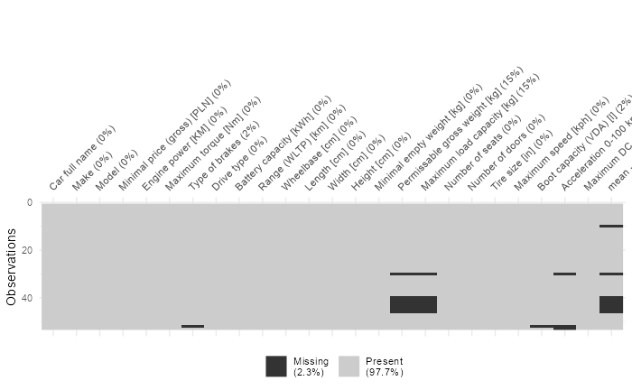

```r
# Visualizando os valores de missing
options(repr.plot.width=15, repr.plot.height = 9)
vis_miss(dados)
```

```r
data_perc <- round(sum(! complete.cases(dados)) / (dim(dados)[1]) * 100, 2)
cat(data_perc, "%")
```

```
20.75 %
```

# Obs

Essa abordagem é adotada quando a quantidade de dados incompletos é considerável e não é possível realizar imputação ou preenchimento adequado dos valores ausentes. A exclusão dessas linhas é uma opção viável para garantir a integridade dos resultados e evitar distorções decorrentes da presença de dados incompletos. No entanto, é importante ressaltar que a exclusão de linhas com valores ausentes implica na perda de informações desses registros específicos. Portanto, antes de tomar essa decisão, é recomendado realizar uma análise cuidadosa e avaliar se a exclusão não introduz um viés ou impacto significativo nos resultados da análise. Além disso, é sempre importante investigar a razão da ausência dos dados. Pode ser necessário investigar se há um padrão ou motivo sistemático para esses valores ausentes, o que pode ter implicações na interpretação dos resultados.

Portanto, ao omitir todas as linhas com valores ausentes, é fundamental considerar os prós e contras dessa decisão, bem como analisar alternativas como imputação de dados ou técnicas estatísticas adequadas para lidar com a incompletude dos registros.

```r
dados <- na.omit(dados)
```

[output not shown]

```r
sum(is.na(dados))
```

```
[1] 0
```

Para a análise em questão, decidimos retirar o nome completo do carro, o fabricante (marca) e o modelo. A exclusão do fabricante se justifica devido à presença de muitos carros com apenas um modelo no dataframe, o que tornaria essa informação menos relevante para a análise estatística.

Ao remover essas informações, estaremos focando em outras variáveis que podem ser mais significativas para a análise, como características técnicas, atributos físicos, informações sobre o desempenho ou consumo de energia, entre outros.

Essa abordagem permite que exploremos os dados de forma mais ampla, identificando padrões e relacionamentos entre as variáveis restantes sem a influência do nome completo do carro ou do fabricante.

É importante destacar que, embora a exclusão dessas informações facilite a análise e a modelagem estatística, isso não significa que o fabricante e o modelo sejam irrelevantes em outras análises ou contextos. Em determinadas situações, essas informações podem desempenhar um papel fundamental na compreensão de certos padrões ou no estudo de características específicas dos veículos.

```r
dados <- dados[,-c(1,2,3)]
```

[output not shown]

```r
head(dados)
```

| Minimal price (gross) [PLN] | Engine power [KM] | Maximum torque [Nm] | Type of brakes | Drive type | Battery capacity [kWh] | Range (WLTP) [km] | Wheelbase [cm] | Length [cm] | Width [cm] | Height [cm] | Minimal empty weight [kg] | Permissable gross weight [kg] | Maximum load capacity [kg] | Number of seats | Number of doors | Tire size [in] | Maximum speed [kph] | Boot capacity (VDA) [l] | Acceleration 0-100 kph [s] | Maximum DC charging power [kW] | mean - Energy consumption [kWh/100 km] |
| --- | --- | --- | --- | --- | --- | --- | --- | --- | --- | --- | --- | --- | --- | --- | --- | --- | --- | --- | --- | --- | --- |
| 345700 | 360 | 664 | disc (front + rear) | 4WD | 95 | 438 | 292.8 | 490.1 | 193.5 | 162.9 | 2565 | 3130 | 640 | 5 | 5 | 19 | 200 | 660 | 5.7 | 150 | 24.45 |
| 308400 | 313 | 540 | disc (front + rear) | 4WD | 71 | 340 | 292.8 | 490.1 | 193.5 | 162.9 | 2445 | 3040 | 670 | 5 | 5 | 19 | 190 | 660 | 6.8 | 150 | 23.80 |
| 414900 | 503 | 973 | disc (front + rear) | 4WD | 95 | 364 | 292.8 | 490.2 | 197.6 | 162.9 | 2695 | 3130 | 565 | 5 | 5 | 20 | 210 | 660 | 4.5 | 150 | 27.55 |
| 319700 | 313 | 540 | disc (front + rear) | 4WD | 71 | 346 | 292.8 | 490.1 | 193.5 | 161.6 | 2445 | 3040 | 640 | 5 | 5 | 19 | 190 | 615 | 6.8 | 150 | 23.30 |
| 357000 | 360 | 664 | disc (front + rear) | 4WD | 95 | 447 | 292.8 | 490.1 | 193.5 | 161.6 | 2595 | 3130 | 670 | 5 | 5 | 19 | 200 | 615 | 5.7 | 150 | 23.85 |
| 426200 | 503 | 973 | disc (front + rear) | 4WD | 95 | 369 | 292.8 | 490.2 | 197.6 | 161.5 | 2695 | 3130 | 565 | 5 | 5 | 20 | 210 | 615 | 4.5 | 150 | 27.20 |

```r
# Renomerando as colunas
data_col <- c("price", "power", "torque",
              "brakes", "drive_type","battery_cap",
              "range", "wheelbase", "length",
              "width", "heigth","min_emp_weight",
              "perm_gross_weigth", "max_load_cap",
              "n_seats","n_doors", "tire_size",
              "max_speed", "boot_cap", "acceleration",
              "max_dc", "energy_consumption")
colnames(dados) <- data_col
```

[output not shown]

```r
# Visualizando dataset
dados
```

| price | power | torque | brakes | drive_type | battery_cap | range | wheelbase | length | width | heigth | min_emp_weight | perm_gross_weigth | max_load_cap | n_seats | n_doors | tire_size | max_speed | boot_cap | acceleration | max_dc | energy_consumption |
| --- | --- | --- | --- | --- | --- | --- | --- | --- | --- | --- | --- | --- | --- | --- | --- | --- | --- | --- | --- | --- | --- |
| 345700 | 360 | 664 | disc (front + rear) | 4WD | 95.0 | 438 | 292.8 | 490.1 | 193.5 | 162.9 | 2565 | 3130 | 640 | 5 | 5 | 19 | 200 | 660 | 5.7 | 150 | 24.45 |
| 308400 | 313 | 540 | disc (front + rear) | 4WD | 71.0 | 340 | 292.8 | 490.1 | 193.5 | 162.9 | 2445 | 3040 | 670 | 5 | 5 | 19 | 190 | 660 | 6.8 | 150 | 23.80 |
| 414900 | 503 | 973 | disc (front + rear) | 4WD | 95.0 | 364 | 292.8 | 490.2 | 197.6 | 162.9 | 2695 | 3130 | 565 | 5 | 5 | 20 | 210 | 660 | 4.5 | 150 | 27.55 |
| 319700 | 313 | 540 | disc (front + rear) | 4WD | 71.0 | 346 | 292.8 | 490.1 | 193.5 | 161.6 | 2445 | 3040 | 640 | 5 | 5 | 19 | 190 | 615 | 6.8 | 150 | 23.30 |
| 357000 | 360 | 664 | disc (front + rear) | 4WD | 95.0 | 447 | 292.8 | 490.1 | 193.5 | 161.6 | 2595 | 3130 | 670 | 5 | 5 | 19 | 200 | 615 | 5.7 | 150 | 23.85 |
| 426200 | 503 | 973 | disc (front + rear) | 4WD | 95.0 | 369 | 292.8 | 490.2 | 197.6 | 161.5 | 2695 | 3130 | 565 | 5 | 5 | 20 | 210 | 615 | 4.5 | 150 | 27.20 |
| 169700 | 170 | 250 | disc (front + rear) | 2WD (rear) | 42.2 | 359 | 257.0 | 400.6 | 179.1 | 157.0 | 1440 | 1730 | 440 | 4 | 5 | 19 | 160 | 260 | 8.1 | 50 | 13.10 |
| 184200 | 184 | 270 | disc (front + rear) | 2WD (rear) | 42.2 | 345 | 257.0 | 400.6 | 179.1 | 159.0 | 1460 | 1730 | 440 | 4 | 5 | 20 | 160 | 260 | 6.9 | 50 | 14.30 |
| 282900 | 286 | 400 | disc (front + rear) | 2WD (rear) | 80.0 | 460 | 286.4 | 473.4 | 189.1 | 166.8 | 2260 | 2725 | 540 | 5 | 5 | 19 | 180 | 510 | 6.8 | 150 | 18.80 |
| 159900 | 136 | 260 | disc (front + rear) | 2WD (front) | 50.0 | 320 | 255.8 | 411.8 | 255.8 | 153.4 | 1523 | 1975 | 450 | 5 | 5 | 17 | 150 | 350 | 8.7 | 100 | 15.60 |

[output cut: 32 more lines]

# Normalização dados

```r
# Verificando as colunas com menos de 5 valores exclusivos e convertendo essas variáveis em fatores
data_unique <- sapply(dados, function(col) length(unique(col))<=5)
dados[, data_unique] <- lapply(dados[ , data_unique], factor)
```

[output not shown]

```r
str(dados)
```

```
tibble [42 × 22] (S3: tbl_df/tbl/data.frame)
 $ price             : num [1:42] 345700 308400 414900 319700 357000 ...
 $ power             : num [1:42] 360 313 503 313 360 503 170 184 286 136 ...
 $ torque            : num [1:42] 664 540 973 540 664 973 250 270 400 260 ...
 $ brakes            : Factor w/ 2 levels "disc (front + rear)",..: 1 1 1 1 1 1 1 1 1 1 ...
 $ drive_type        : Factor w/ 3 levels "2WD (front)",..: 3 3 3 3 3 3 2 2 2 1 ...
 $ battery_cap       : num [1:42] 95 71 95 71 95 95 42.2 42.2 80 50 ...
 $ range             : num [1:42] 438 340 364 346 447 369 359 345 460 320 ...
 $ wheelbase         : num [1:42] 293 293 293 293 293 ...
 $ length            : num [1:42] 490 490 490 490 490 ...
 $ width             : num [1:42] 194 194 198 194 194 ...
 $ heigth            : num [1:42] 163 163 163 162 162 ...
 $ min_emp_weight    : num [1:42] 2565 2445 2695 2445 2595 ...
 $ perm_gross_weigth : num [1:42] 3130 3040 3130 3040 3130 ...
 $ max_load_cap      : num [1:42] 640 670 565 640 670 565 440 440 540 450 ...
 $ n_seats           : Factor w/ 4 levels "2","4","5","8": 3 3 3 3 3 3 2 2 3 3 ...
 $ n_doors           : Factor w/ 3 levels "3","4","5": 3 3 3 3 3 3 3 3 3 3 ...
 $ tire_size         : num [1:42] 19 19 20 19 19 20 19 20 19 17 ...
 $ max_speed         : num [1:42] 200 190 210 190 200 210 160 160 180 150 ...
 $ boot_cap          : num [1:42] 660 660 660 615 615 615 260 260 510 350 ...
 $ acceleration      : num [1:42] 5.7 6.8 4.5 6.8 5.7 4.5 8.1 6.9 6.8 8.7 ...
 $ max_dc            : num [1:42] 150 150 150 150 150 150 50 50 150 100 ...
 $ energy_consumption: num [1:42] 24.4 23.8 27.6 23.3 23.9 ...
 - attr(*, "na.action")= 'omit' Named int [1:11] 10 30 40 41 42 43 44 45 46 52 ...
  ..- attr(*, "names")= chr [1:11] "10" "30" "40" "41" ...
```

```r
rm(data_unique)
```

```r
# Separando variáveis numéricas e variáveis de fator em dois novos dataframe
is_factors1 <- sapply(dados, is.factor)
data_factors1 <- dados[, is_factors1]
head(data_factors1)
```

| brakes | drive_type | n_seats | n_doors |
| --- | --- | --- | --- |
| disc (front + rear) | 4WD | 5 | 5 |
| disc (front + rear) | 4WD | 5 | 5 |
| disc (front + rear) | 4WD | 5 | 5 |
| disc (front + rear) | 4WD | 5 | 5 |
| disc (front + rear) | 4WD | 5 | 5 |
| disc (front + rear) | 4WD | 5 | 5 |

```r
rm(is_factors1)
```

```r
is_numeric1 <- sapply(dados, is.numeric)
data_numeric1 <- dados[, is_numeric1]
head(data_numeric1)
```

| price | power | torque | battery_cap | range | wheelbase | length | width | heigth | min_emp_weight | perm_gross_weigth | max_load_cap | tire_size | max_speed | boot_cap | acceleration | max_dc | energy_consumption |
| --- | --- | --- | --- | --- | --- | --- | --- | --- | --- | --- | --- | --- | --- | --- | --- | --- | --- |
| 345700 | 360 | 664 | 95 | 438 | 292.8 | 490.1 | 193.5 | 162.9 | 2565 | 3130 | 640 | 19 | 200 | 660 | 5.7 | 150 | 24.45 |
| 308400 | 313 | 540 | 71 | 340 | 292.8 | 490.1 | 193.5 | 162.9 | 2445 | 3040 | 670 | 19 | 190 | 660 | 6.8 | 150 | 23.80 |
| 414900 | 503 | 973 | 95 | 364 | 292.8 | 490.2 | 197.6 | 162.9 | 2695 | 3130 | 565 | 20 | 210 | 660 | 4.5 | 150 | 27.55 |
| 319700 | 313 | 540 | 71 | 346 | 292.8 | 490.1 | 193.5 | 161.6 | 2445 | 3040 | 640 | 19 | 190 | 615 | 6.8 | 150 | 23.30 |
| 357000 | 360 | 664 | 95 | 447 | 292.8 | 490.1 | 193.5 | 161.6 | 2595 | 3130 | 670 | 19 | 200 | 615 | 5.7 | 150 | 23.85 |
| 426200 | 503 | 973 | 95 | 369 | 292.8 | 490.2 | 197.6 | 161.5 | 2695 | 3130 | 565 | 20 | 210 | 615 | 4.5 | 150 | 27.20 |

```r
rm(is_numeric1)
```

# Correlação

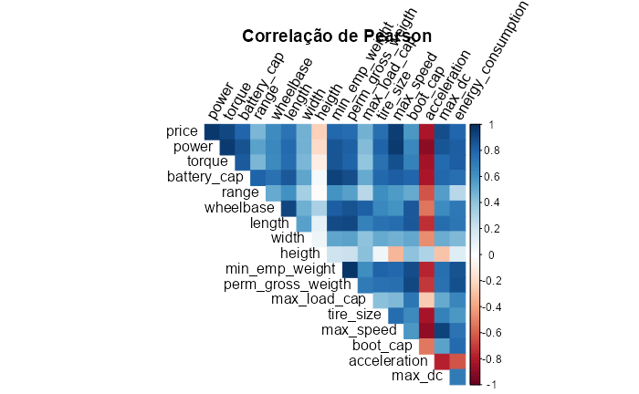

```r
options(repr.plot.width=8, repr.plot.height = 8)
corrplot(cor(data_numeric1), method="color",tl.col= "black",tl.srt=60
         , type = "upper", diag= FALSE)
title('Correlação de Pearson')
```

```r
corr_eng <- cor(data_numeric1[,colnames(data_numeric1) != "energy_consumption"],
                  dados$energy_consumption)
corr_eng
```

```
                        [,1]
price              0.7994474
power              0.8246484
torque             0.8276390
battery_cap        0.7578657
range              0.2744891
wheelbase          0.7164781
length             0.7210755
width              0.4468691
heigth             0.1328584
min_emp_weight     0.8619095
perm_gross_weigth  0.8747710
max_load_cap       0.6500265
tire_size          0.5779794
max_speed          0.7304696
boot_cap           0.7721157
acceleration      -0.6268448
max_dc             0.7093284
```

# Obs

Ao observarmos o gráfico, fica evidente uma alta tendência de correlação entre as variáveis numéricas que estamos analisando. Isso sugere que existe uma relação significativa entre essas variáveis e que elas podem influenciar mutuamente seus respectivos valores.

A correlação entre as variáveis é uma medida estatística que nos ajuda a compreender a força e a direção dessa relação. Uma alta correlação positiva indica que, à medida que o valor de uma variável aumenta, a outra também tende a aumentar. Por outro lado, uma alta correlação negativa indica que, à medida que o valor de uma variável aumenta, a outra tende a diminuir.

Essa alta tendência de correlação entre as variáveis numéricas pode fornecer informações valiosas para a análise. Podemos explorar essas relações para entender melhor como as variáveis estão interconectadas e como uma variável pode ser usada para prever ou explicar variações na outra.No entanto, é importante ressaltar que a correlação não implica necessariamente em causalidade. Ou seja, apenas porque duas variáveis estão correlacionadas, não significa que uma causa a outra. Outros fatores ou variáveis ocultas podem estar envolvidos nessa relação.

Portanto, ao interpretar a alta tendência de correlação entre as variáveis numéricas, devemos considerar cuidadosamente o contexto da análise e explorar outras evidências antes de fazer qualquer inferência causal.

# Feature Selection

```r
data_train <- row.names(which(abs(corr_eng)>0.5, arr.ind = T))
data_train
```

```
 [1] "price"             "power"             "torque"            "battery_cap"       "wheelbase"         "length"            "min_emp_weight"    "perm_gross_weigth" "max_load_cap"      "tire_size"
[11] "max_speed"         "boot_cap"          "acceleration"      "max_dc"
```

```r
data_train <- data_train[! data_train %in% c('length', 'wheelbase', 'min_emp_weight',
                                 'max_load_cap', 'tire_size', 'boot_cap',
                                 'torque', 'max_speed', 'acceleration',
                                 'max_dc')]

data_train
```

```
[1] "price"             "power"             "battery_cap"       "perm_gross_weigth"
```

# Obs

Para uma análise abrangente do consumo de energia, é necessário considerar várias variáveis que podem influenciar esse aspecto. No entanto, para completar o quadro de dados e realizar uma análise específica, a única variável categórica a ser considerada será o tipo de tração, conhecido como “drive_type”.

O tipo de tração pode ser uma informação crucial na determinação do consumo de energia de um veículo. Neste caso, estaremos avaliando se o veículo possui tração nas duas rodas ou tração nas quatro rodas. Essa informação pode ser relevante para compreender como diferentes sistemas de tração afetam o consumo de energia.

Ao incluir o drive_type como variável categórica em nosso modelo, seremos capazes de realizar previsões e análises específicas sobre o consumo de energia com base nessa característica. No entanto, é importante lembrar que outros fatores podem interagir com o tipo de tração e influenciar o consumo, como o peso do veículo, a aerodinâmica, o tipo de motor, entre outros.

Portanto, ao considerar apenas o drive_type como variável categórica em nossa análise, é fundamental ter em mente que essa é apenas uma das muitas variáveis que podem influenciar o consumo de energia do veículo. Para uma análise mais completa e precisa, é recomendado incluir outras variáveis relevantes e realizar uma avaliação mais abrangente do consumo de energia.

```r
data_df <- append(data_train, c('drive_type', 'energy_consumption'))
data_df
```

```
[1] "price"              "power"              "battery_cap"        "perm_gross_weigth"  "drive_type"         "energy_consumption"
```

```r
base <- dados[, data_df]
head(base)
```

| price | power | battery_cap | perm_gross_weigth | drive_type | energy_consumption |
| --- | --- | --- | --- | --- | --- |
| 345700 | 360 | 95 | 3130 | 4WD | 24.45 |
| 308400 | 313 | 71 | 3040 | 4WD | 23.80 |
| 414900 | 503 | 95 | 3130 | 4WD | 27.55 |
| 319700 | 313 | 71 | 3040 | 4WD | 23.30 |
| 357000 | 360 | 95 | 3130 | 4WD | 23.85 |
| 426200 | 503 | 95 | 3130 | 4WD | 27.20 |

```r
str(base)
```

```
tibble [42 × 6] (S3: tbl_df/tbl/data.frame)
 $ price             : num [1:42] 345700 308400 414900 319700 357000 ...
 $ power             : num [1:42] 360 313 503 313 360 503 170 184 286 136 ...
 $ battery_cap       : num [1:42] 95 71 95 71 95 95 42.2 42.2 80 50 ...
 $ perm_gross_weigth : num [1:42] 3130 3040 3130 3040 3130 ...
 $ drive_type        : Factor w/ 3 levels "2WD (front)",..: 3 3 3 3 3 3 2 2 2 1 ...
 $ energy_consumption: num [1:42] 24.4 23.8 27.6 23.3 23.9 ...
 - attr(*, "na.action")= 'omit' Named int [1:11] 10 30 40 41 42 43 44 45 46 52 ...
  ..- attr(*, "names")= chr [1:11] "10" "30" "40" "41" ...
```

```r
base$drive_type <- as.factor(base$drive_type)
str(base)
```

```
tibble [42 × 6] (S3: tbl_df/tbl/data.frame)
 $ price             : num [1:42] 345700 308400 414900 319700 357000 ...
 $ power             : num [1:42] 360 313 503 313 360 503 170 184 286 136 ...
 $ battery_cap       : num [1:42] 95 71 95 71 95 95 42.2 42.2 80 50 ...
 $ perm_gross_weigth : num [1:42] 3130 3040 3130 3040 3130 ...
 $ drive_type        : Factor w/ 3 levels "2WD (front)",..: 3 3 3 3 3 3 2 2 2 1 ...
 $ energy_consumption: num [1:42] 24.4 23.8 27.6 23.3 23.9 ...
 - attr(*, "na.action")= 'omit' Named int [1:11] 10 30 40 41 42 43 44 45 46 52 ...
  ..- attr(*, "names")= chr [1:11] "10" "30" "40" "41" ...
```

# Treino e teste do modelo

```r
# Dividir os dados em conjunto de treinamento (80%) e conjunto de teste (20%)
set.seed(123) # Define uma semente para a reproducibilidade dos resultados
train <- createDataPartition(base$power, p = 0.8, list = FALSE)
x_train <- base[train, ]
y_test <- base[-train, ]
```

# Modelo Machine learning 1 - Regressão linear múltipla

```r
# Treinar o modelo de regressão linear
model_reg_lin <- lm(energy_consumption ~.,
                    data = x_train)
model_reg_lin
```

```
Call:
lm(formula = energy_consumption ~ ., data = x_train)

Coefficients:
         (Intercept)                 price                 power           battery_cap     perm_gross_weigth  drive_type2WD (rear)         drive_type4WD
           7.252e+00             6.885e-06            -3.279e-04            -4.653e-02             5.202e-03            -3.628e-01             2.471e+00
```

```r
# Summary modelo
summary(model_reg_lin)
```

```
Call:
lm(formula = energy_consumption ~ ., data = x_train)

Residuals:
    Min      1Q  Median      3Q     Max
-3.1445 -0.9394 -0.2164  0.8681  4.2171

Coefficients:
                       Estimate Std. Error t value Pr(>|t|)
(Intercept)           7.252e+00  2.166e+00   3.348 0.002407 **
price                 6.885e-06  7.679e-06   0.897 0.377818
power                -3.279e-04  1.097e-02  -0.030 0.976370
battery_cap          -4.653e-02  3.441e-02  -1.352 0.187570
perm_gross_weigth     5.202e-03  1.345e-03   3.868 0.000627 ***
drive_type2WD (rear) -3.628e-01  8.063e-01  -0.450 0.656277
drive_type4WD         2.471e+00  1.766e+00   1.400 0.172967
---
Signif. codes:  0 ‘***’ 0.001 ‘**’ 0.01 ‘*’ 0.05 ‘.’ 0.1 ‘ ’ 1

Residual standard error: 1.774 on 27 degrees of freedom
Multiple R-squared:  0.8471,    Adjusted R-squared:  0.8131
F-statistic: 24.93 on 6 and 27 DF,  p-value: 8.089e-10
```

```r
# Previsãoes modelo 1
pred_reg <- predict(model_reg_lin, newdata = y_test)
pred_reg
```

```
       1        2        3        4        5        6        7        8
24.27831 15.13376 16.72481 16.55839 16.32708 15.71917 24.02505 13.52576
```

```r
# Calcular o erro médio absoluto (MAE)
mae <- mean(abs(y_test$energy_consumption - pred_reg))
cat("Erro Médio Absoluto (MAE):", mae, "\n")
```

```
Erro Médio Absoluto (MAE): 1.421864
```

```r
# Calcular o coeficiente de determinação (R²)
r_squared <- cor(y_test$energy_consumption, pred_reg)^2
cat("Coeficiente de Determinação (R²):", r_squared, "\n")
```

```
Coeficiente de Determinação (R²): 0.8657182
```